## Open-Science-Thesis

### About

The Open-Science-Thesis [repository](https://github.com/cpfaff/Open-Science-Thesis) contains a LaTeX document packed into a logical file and folder structure that you can use as a scaffold for your next writing project. The document is thought to be forked and used for scientific thesis writing while keeping the document under version control with git and GitHub. The Open-Science-Thesis combines the typesetting capabilities of LaTeX with the R programming language for statistics, using the [Knitr](http://yihui.name/knitr/) R package. This combination allows to create executable documents for a better reproducibility of your research documents.

The Open-Science-Thesis offers a clean and logical folder structure and contains many examples of typical typesetting requirements you have to deal with when writing a thesis (title-page, tables, figures, affidavit, …). On top of that the scaffold comes with its own simple makefile that helps you to compile (translate to PDF), clean and archive your document on the command line. For an example on the style of the Open-Science-Thesis just have a look into the [PDF](https://github.com/cpfaff/Open-Science-Thesis/blob/master/open_science_thesis.pdf) file that is contained in this repository or just scroll further down into the sections below.

### Development Note

This project is still in lively development and the commands, environments and the layout provided by the LaTeX class can be subject to change! You might also find the current version in master branch in unstable state so a compilation to PDF is not possible with that version! Thus I recommend you to checkout the versions that you can find under the `Releases` in the upper part of that repository homepage.

### Use LaTeX-Class only

You might be in the situation that you do not like to use the complete document scaffold presented here. That is no problem at all as you can also just download and use the Open-Science-Thesis LaTeX-Class and use it as document class for your own LaTeX documents. You can [download](http://bit.ly/1dowUNP) the class file, then save it into the same folder as your own `main_document.tex` file and then load the class in your preamble:

```latex
\documentclass[options]{open_science_thesis}

% preamble

\begin{document}

% body

\end{document}
```

NOTE:

There is no `.cls` appended to the name when loading the class.

## User interface

The Open Science Thesis class is based on several fine LaTeX packages and tries to serve a clean and logical user interface that helps you deal with most of your typesetting requirements. You can handle line spacing, justification and various other parameters globally by class options. Additionally there are commands that you can use in your preamble to set the content (e.g. title, predefined headings), or to control the color and the size of literally any element in your document using its name as reference reference.

- Example for the user interface:

```latex
% set the conent of a field
\ostSetContent{Title}{This is the title of my document}

% set the stlye of a field
\ostSetSize{Title}{\Huge}
\ostSetFont{Title}{\itshape}
\ostSetColor{Title}{green}
```

There is also a one line command that covers the full range of styling an element.

```latex
\ostSetStyle{<name>}{<size>}{<font>}{<colorname>}
% e.g for the title like above
\ostSetStyle{Title}{\Huge}{\itshape}{green}
```

With this interface it is simple to change the content, the font and the color of an element, using its name, in a clean and readable way. Here the `Title` that appears on the documents title-page is filled with content, set to text size `\Huge` and it will appear in an italic shape with green color. To find more names of elements you can modify read through the sections below.

NOTE:

One note about commands provided by the class: You can distinguish between commands that go into your preamble and the ones you can use in your document body by their casing. While the camel case commands always have to go into the preamble the small case only commands are suitable for your document body.

### Title pages

In order to get a title-page you need to set the contents of the title-page fields in your preamble. As the class defines defaults for each of the fields, you need to set the content of a field to empty if you decide not to use it.

```latex
\ostSetContent{Title}{My own title}
\ostSetContent{Subtitle}{The subtitle}
\ostSetContent{Authors}{Authors}
\ostSetContent{Date}{10.10.1983}
\ostSetContent{AdvisorOne}{Advisor: \\ Markus Muggel\\ Hogstreet 1\\ Telephone 1234234}
\ostSetContent{AdvisorTwo}{Alexus Quercus\\ Hogstreet 1\\ Telephone 1234234}
% example where advisor two is not used
\ostSetContent{AdvisorTwo}{}
```

After setting the contents of the title-page elements you can print out the title-page using the command `\maketitle` in your document body. There is also an alias called `\printtitlepage` which does exactly the same.

```latex
\begin{document}
    \maketitle
    % alias: \printtitlepage
\end{document}
```

The class defines four layouts for title pages you can choose from. You can switch the styles via the following class option:

```latex
\documentclass[titlepagetheme=vertical]{open_science_thesis}
```

Some of the title-pages have additional elements associated with them which are listed along with the layout theme examples below. These elements names can be used as explained above to modify content and style.

- vertical

```latex
% set the text on the bar
\ostSetContent{TextOnBar}{Text on vertical bar}
\ostSetFont{TextOnBar}{\Huge}
\ostSetColor{TextOnBar}{red}
```

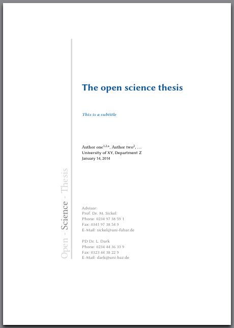

- horizontal

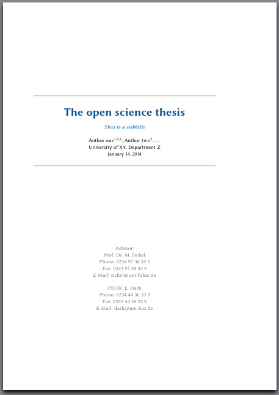

- image

```latex
% set image
\ostSetImage{TitlepageBackground}{pathto/image.png}
```

Sets up a typesetting area centered image for title-page background. You can also modify the image in width as well as you can adjust it via a horizontal and vertical offset to make it appear where you like.

```latex
% or with options
\ostSetImage[width=5cm, voffset=1cm, hoffset=1cm]{TitlepageBackground}{pathto/image.png}
```

- `width` adjust with of the image
- `voffset` adjust image vertically
- `hoffset` adjust image horizontally

Depending on the image in the background and the text color you use for your title-page contents it can happen that the text becomes hard to read. In that case you can set and modify an overlay that goes between your title-page text and the background image.

```latex
% set opacity of overlay for better reading of title content
% set between 0-1
\ostSetOpacity{TitleOverlay}{0.7}

% set color of overlay
\ostSetColor{TitleOverlay}{gray}
```

NOTE:

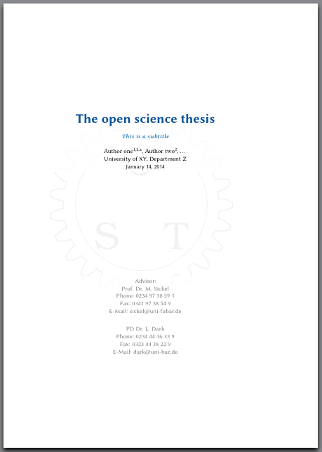

- plain

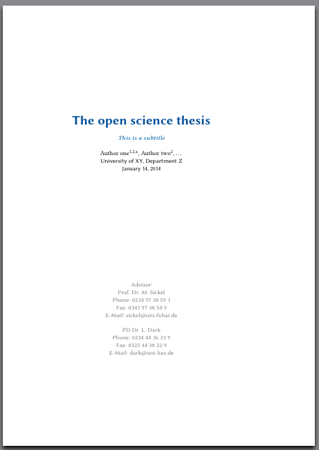

#### Colors and fonts

You can set the font shapes, sizes and colors on the title page using the following elements names and commands:

- colors

```latex
\ostSetColor{Title}{SteelBlue}
\ostSetColor{Subtitle}{SteelBlue}
\ostSetColor{Authors}{SteelBlue}
\ostSetColor{Date}{SteelBlue}
\ostSetColor{Advisor}{SteelBlue}
```

- fonts

```latex
\ostSetFont{Title}{\bfseries}
\ostSetFont{Subtitle}{\bfseries}
\ostSetFont{Authors}{...}
\ostSetFont{Date}{...}
\ostSetFont{Advisor}{...}
```

### Table of Contents

You can create the table of contents using the following LaTeX commands.

```
\tableofcontents
\listoffigures
\listoftables
```

Additionally the Open-Science-Thesis provides a convenient replacement for these commands which creates all these tables for you using a single command. This convenient alternative also creates a list of revision notes when the document is compiled in revision mode (see below).

```latex
\makeallcontenttables
% alias: \printallcontenttables
```

- Nice styled table of contents

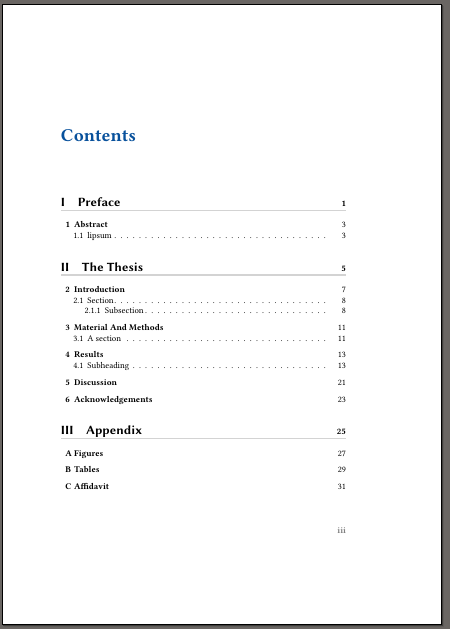

- Nice formatted parts and partial table of contents either on part

```latex
\documentclass[toctosection=part]{open_science_thesis}
```

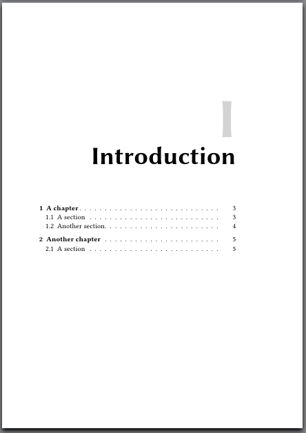

- or chapter sections

```latex
\documentclass[toctosection=chapter]{open_science_thesis}
```

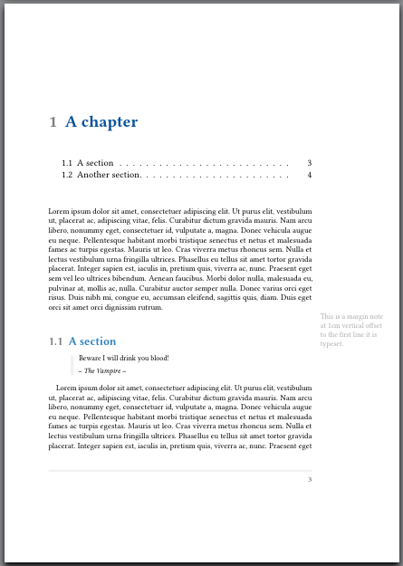

### Lettrines + coloring

The Open-Science-Thesis class comes with four predefined color schemes. You can choose by the following class option:

```latex
\documentclass[colortheme=orange]{open_science_thesis}
```

- orange

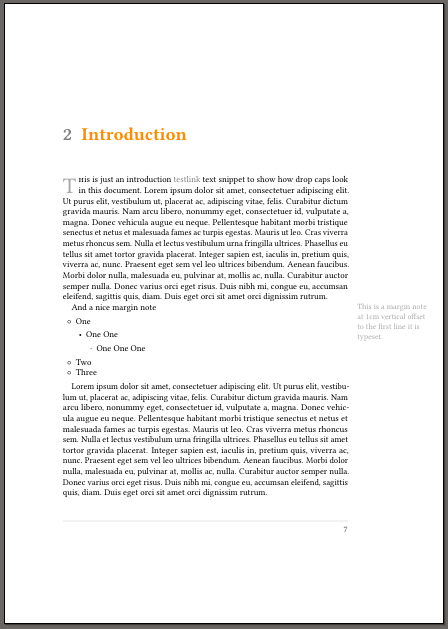

- blue

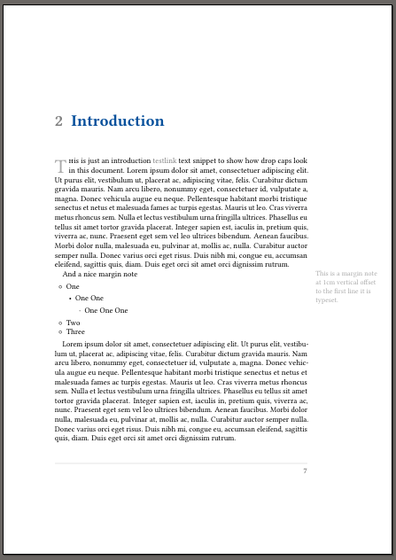

- green

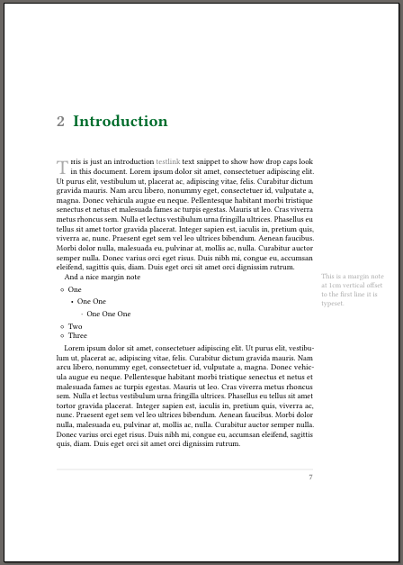

- red

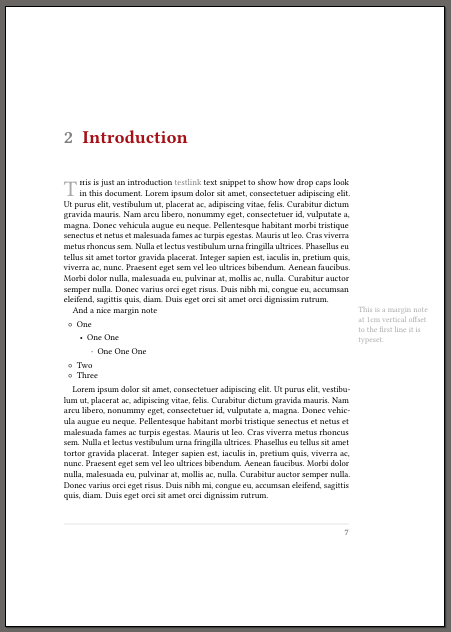

#### Own color theme

You can set the color of almost any element in the document via the styling commands the Open-Science-Thesis class provides you with. The most prominent elements that follow the color theme are the title page elements, sections and the label for the captions. You can set your own color theme by setting the following named elements colors in your preamble:

```latex
\ostSetColor{Title}{DarkOrange}
\ostSetColor{Subtitle}{DarkOrange}
\ostSetColor{ChapterHeader}{DarkOrange}
\ostSetColor{SectionHeader}{DarkOrange}
\ostSetColor{SubsectionHeader}{DarkOrange}
\ostSetColor{SubSubsectionHeader}{DarkOrange}
\ostSetColor{ParagraphHeader}{DarkOrange}
\ostSetColor{CaptionLabel}{DarkOrange}
```

This is a list of other elements you can change the color and style from:

```latex
\ostSetColor{TitleRule}{black}
\ostSetColor{TitleRuleVertical}{black}
\ostSetColor{TextOnBar}{black}
\ostSetColor{TocRule}{black}
\ostSetColor{PartialToc}{black}
\ostSetColor{TitleOverlay}{white}
\ostSetColor{ImageFrame}{black}
\ostSetColor{Title}{black}
\ostSetColor{Subtitle}{black}
\ostSetColor{Authors}{black}
\ostSetColor{Institution}{black}
\ostSetColor{Advisors}{black}
\ostSetColor{Date}{black}
\ostSetColor{MarginNote}{black}
\ostSetColor{Advisors}{black}
\ostSetColor{CaptionLabel}{black}
\ostSetColor{PartHeader}{black}
\ostSetColor{PartHeaderNumber}{black}
\ostSetColor{ChapterHeader}{black}
\ostSetColor{ChapterHeaderNumber}{black}
\ostSetColor{SectionHeader}{black}
\ostSetColor{SectionHeaderNumber}{black}
\ostSetColor{SubsectionHeader}{black}
\ostSetColor{SubsectionHeaderNumber}{black}
\ostSetColor{SubSubsectionHeader}{black}
\ostSetColor{SubSubsectionHeaderNumber}{black}
\ostSetColor{ParagraphHeader}{black}
\ostSetColor{ParagraphHeaderNumber}{black}
\ostSetColor{Lettrine}{black}
\ostSetColor{LineNumber}{black}
\ostSetColor{HeaderRule}{black}
\ostSetColor{FooterRule}{black}
\ostSetColor{HeaderMarks}{black}
\ostSetColor{PageNumber}{black}
\ostSetColor{PageNumberSurrounding}{black}
\ostSetColor{Links}{black}
\ostSetColor{CitationLinks}{black}
\ostSetColor{FileLinks}{black}
\ostSetColor{MenuLinks}{black}
\ostSetColor{URLLinks}{black}
```

### Fonts

You can modify the use of fonts globally by the following class option.

```latex
\documentclass[fontchoice={lmodern, libertine, times, palatino, utopia}]{open_science_thesis}
% defaults to the libertine fonts
```

### Global formatting

You can change the line spacing globally by `linespacing` class option.

```latex
\documentclass[linespacing={onehalfspacing, doublespacing}]{open_science_thesis}
```

- `onehalfspacing` switches globally to one and half space
- `doublespacing` switches globally double space

But globally does not mean it affects all elements. I is selectively applied to some elements only. It does not affect the title-page or any of the table of contents neither the margin notes nor bullet, numbered or description lists. There is also no space adjustment applied to the affidavit and the bibliography content. If you prefer to have the line spacing applied on any content in you document you need to disable `sensitivespacing`.

```latex
\documentclass[sentivspacing=false]{open_science_thesis}
```

You can change the justification globally by the `justification` class option.

```latex
\documentclass[justification={centered, raggedleft, raggedright}]{open_science_thesis}
```

### Float control

You can add float barriers to various headers so you get a better control over floats. That will ensure floats will not float over one of these and will just printed out before latex goes on with next sectioning.

```latex
\documentclass[addfloatbarrierto={part, chapter, section}]{open_science_thesis}
```

### Bibliography (based on biblatex)

You can modify the style of your bibliography:

```latex
\documentclass[style=, citestyle=, bibstyle=, natbib=]{open_science_thesis}
```

Then add a bibliography file `*.bib` in your preamble

```latex
\ostAddBibliography{path/to/test.bib}
```

### Lists (spacing and symbols)

- `compactlist` gives you more compact lists
- `fancylist` redefines the spacing and symbols used in lists

```latex
\documentclass[compactlist={true,false}, fancylist={true,false}]{open_science_thesis}
```

### Quotations

```latex
\barquote[author=test]{You nice quote}
% author is optional
```

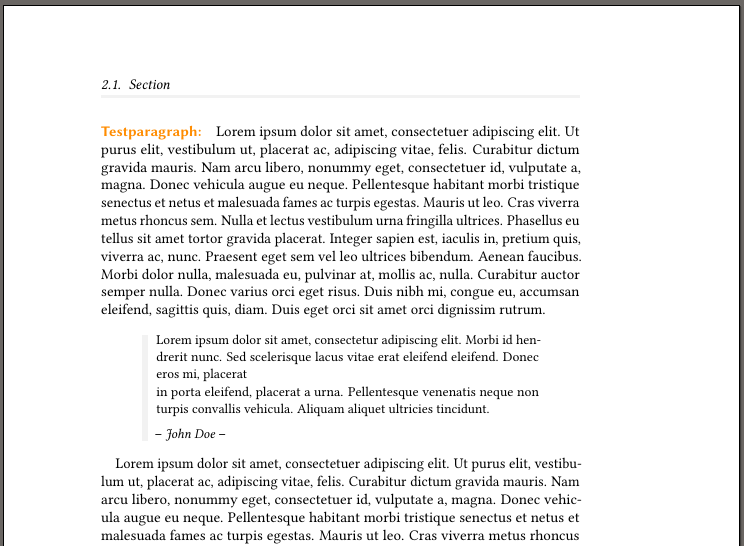

### Frames for images

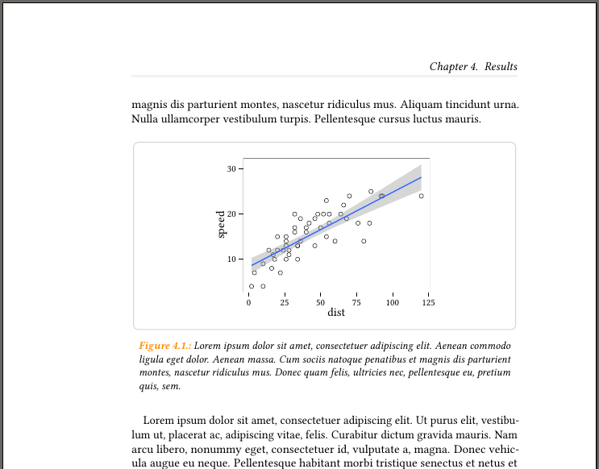

```latex
\framedfigure[placement={H,h,t,b,p}, label=yourlabel]{\includegraphics...}{caption}
```

### Tables (booktabs)

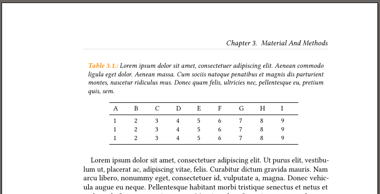

### Code Listings (in solarized color theme)

- The code listings follow the solarized color theme by default.

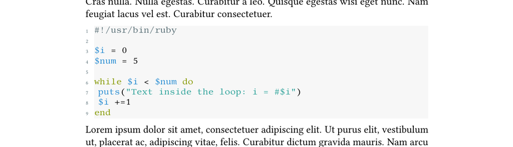

NOTE:

The elements names of the code listings are protected in the class. This means they cannot simply be changed like described above. The names contain an `@` character that is not valid in a normal LaTeX document as it has a special meaning. In order to be able to change the elements you need to put the commands into a style file that can be included in your preamble. However you could also change it directly in you preamble using the following construct.

```latex
\makeatletter
\ostSetColor{@ListingBackground}{gray}
\ostSetColor{@ListingBase00}{gray}
\ostSetColor{@ListingBase01}{gray}
\ostSetColor{@ListingBase02}{gray}
\ostSetColor{@ListingBase03}{gray}
\ostSetColor{@ListingBase0}{gray}
\ostSetColor{@ListingBase1}{gray}
\ostSetColor{@ListingBase2}{gray}
\ostSetColor{@ListingBase3}{gray}
\ostSetColor{@ListingYellow}{gray}
\ostSetColor{@ListingOrange}{gray}
\ostSetColor{@ListingRed}{gray}
\ostSetColor{@ListingMagenta}{gray}
\ostSetColor{@ListingViolet}{gray}
\ostSetColor{@ListingBlue}{gray}
\ostSetColor{@ListingCyan}{gray}
\ostSetColor{@ListingGreen}{gray}
\makeatother
```

You can typeset in-line code listings as well that follow the same style as code-boxes using the command below.

```latex
\inlinecode{a+b=c}
```

You can change the style of in-line code boxes globally between `round` and `box` and `plain` with:

```latex
\documentclass[inlinecodestyle={round, box, plain}]{open_science_thesis}
```

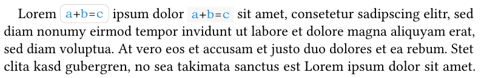

### Revisions (based on todonotes)

If you like somebody to comment on your document you can do this with the revision mechanism. The fist you need to to is set up the revisor using the command below with a name.

```latex
\ostSetRevisor{Claas}
```

After that the revisor can comment in-linke using the name that has been set up.

```latex
Lorem ipsum dolor sit amet, consectetur adipisicing elit, sed do eiusmod tempor
incididunt ut labore et dolore magna aliqua. Ut enim ad minim veniam, quis
nostrud exercitation ullamco laboris nisi ut aliquip ex ea commodo consequat.
Duis aute irure dolor in reprehenderit in voluptate velit esse cillum dolore eu
fugiat nulla pariatur. Excepteur sint occaecat cupidatat non proident, sunt in
culpa qui officia deserunt mollit anim id est laborum \Claas{This is so nice}
```

To show the comments you can compile the document in revision mode. This will set up the page to be larger (A3) but keeps the typesetting area the same. Additionally line numbers are enabled and comments from revisors are shown as margin notes.

```latex
\documentclass[revision=true]{open_science_thesis}
```

NOTE:

You can disable the revision mode removing or just disabling the class option. This will then compile as normal and ignore the comments of revisors. However you need to leave the revisor setup command in place as otherwise the command will be unknown and the compilation fails.

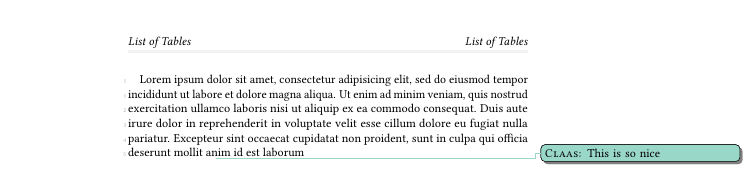

NOTE:

This mechanism is picking colors automatically for 5 different revisors.

### Header and footer (fancyhdr)

Header and footer are setup by the open science thesis with predefined parameters. If you are not happy with the styling you can change the font attributes with the commands below:

```latex
\ostSetSize{HeaderMarks}{\Large}
\ostSetFont{HeaderMarks}{\scshape}
\ostSetColor{HeaderMarks}{red}

\ostSetSize{FooterMarks}{\Large}
\ostSetFont{FooterMarks}{\itshape}
\ostSetColor{FooterMarks}{green}
```

If you are not happy with the content in the header or the footer you can setup the fields to your needs. As the `fancyhdr` package offers a very nice interface for modifications to the header and the footer, the commands below operate directly on these. However the Open-Science-Thesis class offers aliases to make the commands follow the naming of commands in the Open-Science-Thesis class.

```latex
\ostHeaderSetup{<places comma separated>}{<content>}
\ostFooterSetup{<places comma separated>}{<content>}
```

The setup of size, font and color of the header and footer marks as shown above will also apply to your setup with these commands.

An example:

```latex
\ostHeaderSetup{LO,RE}{testcontent}
\ostHeaderSetup{RO,LE}{the other}
\ostHeaderSetup{C}{the center}
\ostFooterSetup{LO,RE}{testcontent}
\ostFooterSetup{RO,LE}{the other}
\ostFooterSetup{C}{the center}
```

As placements are allowed:

- for twoside documents:
  - `LO` left odd
  - `LE` left even
  - `RO` right odd
  - `RE` right even
  - `C` center
- for oneside documents:
  - `L` left
  - `R` right
  - `C` center

Header and footer rules can be changed by following commands.

```latex
\ostSetHeight{HeaderRule}{3pt}
\ostSetColor{HeaderRule}{red}
% width is not settable atm

\ostSetHeight{FooterRule}{3pt}
\ostSetColor{FooterRule}{red}
% width is not settable atm
```

### Affidavit

You can print out a predefined affidavit using one single command.

```latex
\makeaffidavit
% alias: \printaffidavit
```

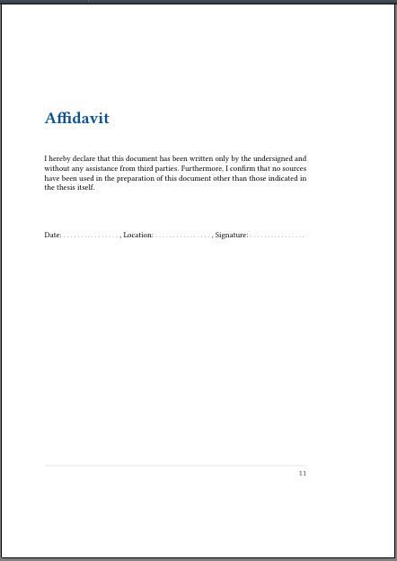

The contents of the affidavit can be changed with:

```latex
\ostSetContent{AffidavitName}{Declaration}
\ostSetContent{AffidavitText}{This work has been done by me and nobody else!}
\ostSetContent{AffidavitDate}{19.11.1981}
\ostSetContent{AffidavitLocation}{Stuttgart}
```

### Set predefined names

LaTeX comes with some built-in names that change automatically if you change the language with the babel package. You can change the names with:

```latex
\ostSetContent{TableOfContentsName}{Content}
\ostSetContent{ListOfFiguresName}{Figures}
\ostSetContent{ListOfTablesName}{Tables}
\ostSetContent{BibliographyName}{Biblio}
\ostSetContent{AffidavitName}{Declaration}
```

## See also

The Open-Science-Thesis is one of a series of document classes or project scaffolds. You might also be interested in one of the following repositories.

- Open-Science-Paper
- Open-Science-Poster

## Self-promotion

Do you like the Open-Science-Thesis repository? You are welcome to follow me on [GitHub](https://github.com/cpfaff) and or [Twitter](http://twitter.com/ctpfaff).

## License

This work is licensed under a [Creative Commons Attribution-NonCommercial-ShareAlike 3.0 Unported License](http://creativecommons.org/licenses/by-nc-sa/3.0/).